# Combined Dataset Overview

TI Senior Design — Shahed Drone Detection

Four sources reconciled into one two-class scheme (`other`, `shahed`), cleaned data: duplicate images removed, and every label validated against its image.

**Covered here:** class balance, per-source composition, and a visual spot-check of the annotations. Training on this dataset is the next step, once the composition below has been reviewed.

## Configuration

```python
from pathlib import Path
from collections import Counter, defaultdict

import matplotlib.pyplot as plt
import matplotlib.patches as patches
from PIL import Image

COMBINED_DIR = Path("/Users/sandra/Documents/Fall 26/Senior Design/DataSets/combined_dataset")
FINAL_NAMES = ["other", "shahed"]
SPLITS = ["train", "valid"]

# Palette: fixed categorical order, validated for adjacent-pair contrast
PALETTE = ["#2a78d6", "#eb6834", "#1baf7a", "#eda100"]
INK = "#0b0b0b"
MUTED = "#898781"
GRIDLINE = "#e1e0d9"

plt.rcParams.update({
    "font.family": "sans-serif",
    "axes.edgecolor": GRIDLINE,
    "axes.labelcolor": MUTED,
    "xtick.color": MUTED,
    "ytick.color": MUTED,
    "text.color": INK,
})
```

## Dataset composition

```python
def scan_split(split):
    """Return one record per image: (source, class_counts) for the given split."""
    labels_dir = COMBINED_DIR / split / "labels"
    records = []
    for label_path in sorted(labels_dir.glob("*.txt")):
        source = label_path.stem.split("__", 1)[0]
        classes = Counter()
        with open(label_path) as f:
            for line in f:
                line = line.strip()
                if line:
                    classes[int(line.split()[0])] += 1
        records.append((source, classes))
    return records

split_records = {split: scan_split(split) for split in SPLITS}
for split, records in split_records.items():
    print(f"{split}: {len(records)} images")
```

```
train: 8527 images
valid: 1504 images
```

```python
summary_rows = []
for split, records in split_records.items():
    by_source = Counter(source for source, _ in records)
    for source, count in sorted(by_source.items()):
        summary_rows.append((split, source, count))

print(f"{'split':<8}{'source':<28}{'images':>8}")
for split, source, count in summary_rows:
    print(f"{split:<8}{source:<28}{count:>8}")
```

```
split   source                        images
train   aod4                            4351
train   shahed136_youtube                 21
train   shahed_dataset_1_synthetic      3985
train   shahed_roboflow                  170
valid   aod4                             811
valid   shahed136_youtube                  4
valid   shahed_dataset_1_synthetic       666
valid   shahed_roboflow                   23
```

## Class distribution

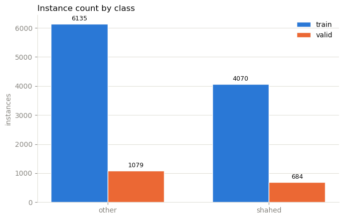

```python
class_counts_by_split = {
    split: Counter(cls for _, classes in records for cls, n in classes.items() for _ in range(n))
    for split, records in split_records.items()
}

fig, ax = plt.subplots(figsize=(7, 4.5))
x = range(len(FINAL_NAMES))
bar_width = 0.35

for i, split in enumerate(SPLITS):
    counts = [class_counts_by_split[split].get(cls_id, 0) for cls_id in range(len(FINAL_NAMES))]
    offset = (i - 0.5) * bar_width
    bars = ax.bar([xi + offset for xi in x], counts, width=bar_width,
                  color=PALETTE[i], label=split, edgecolor="#fcfcfb", linewidth=1)
    ax.bar_label(bars, padding=3, color=INK, fontsize=9)

ax.set_xticks(list(x))
ax.set_xticklabels(FINAL_NAMES)
ax.set_ylabel("instances")
ax.set_title("Instance count by class", color=INK, fontsize=12, loc="left")
ax.grid(axis="y", color=GRIDLINE, linewidth=0.8)
ax.set_axisbelow(True)
for spine in ["top", "right"]:
    ax.spines[spine].set_visible(False)
ax.legend(frameon=False)
plt.tight_layout()
plt.show()
```

If `other` outnumbers `shahed` by a wide margin, that imbalance comes primarily from AOD4 (helicopters folded into `other`) and is worth a decision before training: downsample `other`, oversample `shahed`, or apply class weighting.

## Source contribution

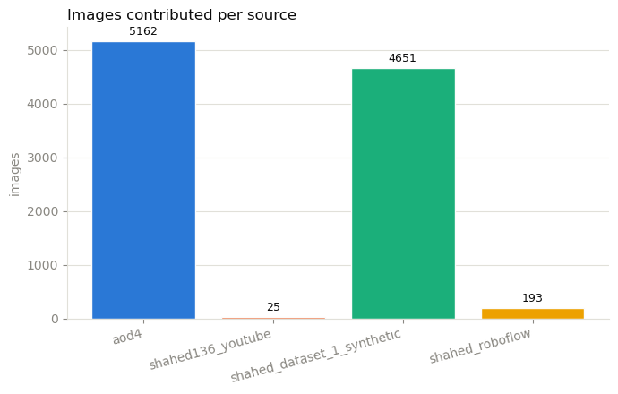

```python
source_totals = Counter()
for records in split_records.values():
    source_totals.update(source for source, _ in records)

sources = sorted(source_totals)
counts = [source_totals[s] for s in sources]

fig, ax = plt.subplots(figsize=(7, 4.5))
bars = ax.bar(sources, counts, color=PALETTE[: len(sources)], edgecolor="#fcfcfb", linewidth=1)
ax.bar_label(bars, padding=3, color=INK, fontsize=9)

ax.set_ylabel("images")
ax.set_title("Images contributed per source", color=INK, fontsize=12, loc="left")
ax.grid(axis="y", color=GRIDLINE, linewidth=0.8)
ax.set_axisbelow(True)
for spine in ["top", "right"]:
    ax.spines[spine].set_visible(False)
plt.xticks(rotation=15, ha="right")
plt.tight_layout()
plt.show()
```

## Sample annotations

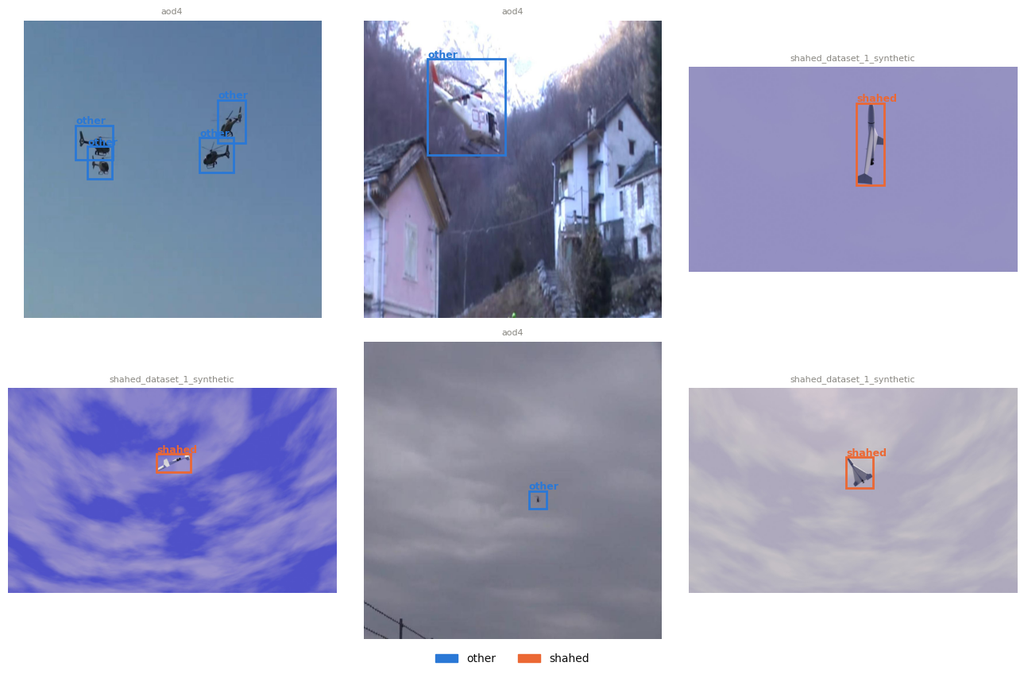

```python
import random
random.seed(42)

CLASS_COLOR = {"other": PALETTE[0], "shahed": PALETTE[1]}

images_dir = COMBINED_DIR / "train" / "images"
labels_dir = COMBINED_DIR / "train" / "labels"
label_paths = list(labels_dir.glob("*.txt"))
samples = random.sample(label_paths, min(6, len(label_paths)))

fig, axes = plt.subplots(2, 3, figsize=(13, 8.5))
for ax, label_path in zip(axes.flatten(), samples):
    image_path = next(images_dir.glob(f"{label_path.stem}.*"))
    img = Image.open(image_path).convert("RGB")
    w, h = img.size

    ax.imshow(img)
    ax.set_title(label_path.stem.split("__", 1)[0], fontsize=8, color=MUTED)
    ax.axis("off")

    with open(label_path) as f:
        for line in f:
            cls_id, xc, yc, bw, bh = (float(v) for v in line.split())
            name = FINAL_NAMES[int(cls_id)]
            color = CLASS_COLOR[name]
            x1, y1 = (xc - bw / 2) * w, (yc - bh / 2) * h
            rect = patches.Rectangle((x1, y1), bw * w, bh * h, linewidth=2,
                                      edgecolor=color, facecolor="none")
            ax.add_patch(rect)
            ax.text(x1, max(y1 - 6, 0), name, color=color, fontsize=9, weight="bold")

handles = [patches.Patch(color=c, label=n) for n, c in CLASS_COLOR.items()]
fig.legend(handles=handles, loc="lower center", ncol=2, frameon=False)
plt.tight_layout(rect=[0, 0.03, 1, 1])
plt.show()
```

## Next steps

- Review the class balance above with the team and decide on a mitigation if `other` dominates (downsample, oversample, or class weighting).
- Fine-tune yolov4-tiny on this combined dataset — training pipeline is ready as a separate step once the above is settled.
- Evaluate precision/recall per class on the held-out validation split, not just aggregate mAP.
- Export the trained model to ONNX for TI Edge AI Studio / TIDL compilation (stretch goal).